# Machine Learning Project ASmyth

Abigail Smyth

June 1, 2020

## Machine Learning Course Project

We will be using data collected from devices such as Jawbone Up, Nike FuelBand, and Fitbit to build a model to predict the manner in which an exercise was done. We will be reviewing data collected on the belt, forearm, arm, and dumbell of 6 participants that were asked to perform barbell lifts correctly and incorrectly in 5 different ways. We will use this data to build a prediction model to determine the classe variable.

## Summary

We begin with importing the training data set, reviewing the data, removing columns that contain N/A to remove insignificant data. This brings the dataset from 160 columns down to 60 columns. In reviewing the research paper (http://groupware.les.inf.puc-rio.br/har#literature), it is clear that the first 7 columns have no impact on predicting the class and we will remove them as well, bringing our dataset down to 52 predictors. We then split the data set into a training and test set (.70 / .30).

Looking at the classe variable, we see that the highest percentage - 28% of the exercises - fall in classe A (or the classe where the exercise was correctly completed).

Models compared were Decision Tree, Random Forest and Naive Bayes. Random forest had the highest accuracy at 99%.

```r
library(caret)
library(randomForest)
library(rattle)
train <- read.csv("pml-training.csv", na.strings=c("NA", "#DIV/0!", "", " "));
test  <- read.csv("pml-testing.csv", na.strings=c("NA", "#DIV/0!", "", " "));


train <- train[-c(1:7)];         # remove first 7 columns
test  <- test[-c(1:7,160)];      # remove first 7 and result column

# function to verify existence of atleast one NA value in a given column
is.na.column = function(col){
   any(is.na(col))
}

cols <- names(train);
non.empty.columns <- which(!sapply(train,is.na.column));
train <- train[,non.empty.columns]

cols <- names(test);
non.empty.columns <- which(!sapply(test,is.na.column));
test <- test[,non.empty.columns]

dim(train);
```

```
## [1] 19622    53
```

```r
summary(train$classe)
```

```
##    A    B    C    D    E
## 5580 3797 3422 3216 3607
```

```r
dim(test);
```

```
## [1] 20 52
```

```r
trainIndex <- createDataPartition(y=train$classe, p=0.70, list=FALSE);
trainSet <- train[trainIndex,];
testSet <- train[-trainIndex,];
```

## Decision Tree Model - ~49% accuracy

```r
modTree <- train(classe ~ ., data=trainSet, method="rpart")
print(modTree$finalModel)
```

```
## n= 13737
##
## node), split, n, loss, yval, (yprob)
##       * denotes terminal node
##
##  1) root 13737 9831 A (0.28 0.19 0.17 0.16 0.18)
##    2) roll_belt< 130.5 12605 8711 A (0.31 0.21 0.19 0.18 0.11)
##      4) pitch_forearm< -34.6 1101    2 A (1 0.0018 0 0 0) *
##      5) pitch_forearm>=-34.6 11504 8709 A (0.24 0.23 0.21 0.2 0.12)
##       10) magnet_dumbbell_y< 439.5 9738 6993 A (0.28 0.18 0.24 0.19 0.11)
##         20) roll_forearm< 125.5 6120 3654 A (0.4 0.18 0.18 0.17 0.063) *
##         21) roll_forearm>=125.5 3618 2422 C (0.077 0.17 0.33 0.23 0.19) *
##       11) magnet_dumbbell_y>=439.5 1766  859 B (0.028 0.51 0.04 0.22 0.19) *
##    3) roll_belt>=130.5 1132   12 E (0.011 0 0 0 0.99) *
```

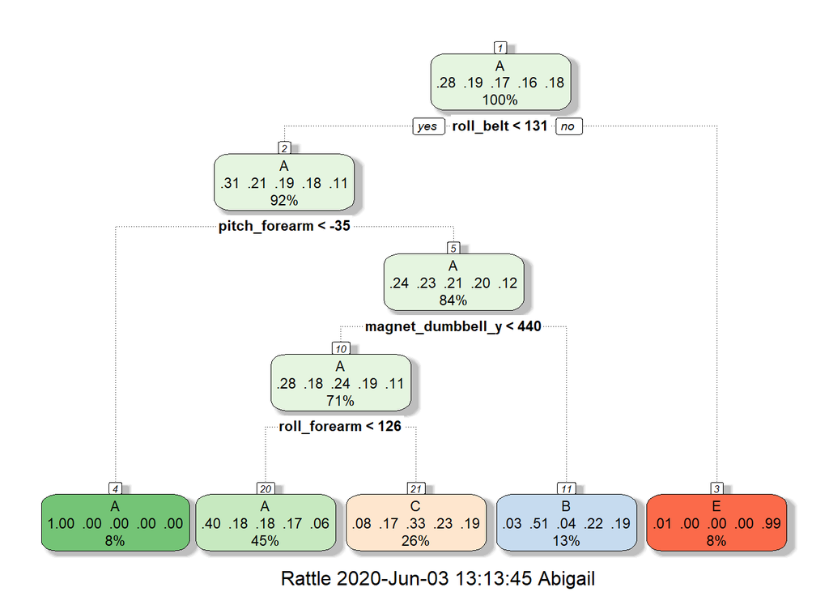

```r
fancyRpartPlot(modTree$finalModel)
```

```r
predTree <- predict(modTree, testSet)
cmTree <- confusionMatrix(predTree, testSet$classe)
print(cmTree);
```

```
## Confusion Matrix and Statistics
##
##           Reference
## Prediction    A    B    C    D    E
##          A 1521  487  476  439  138
##          B   31  379   37  172  144
##          C  120  273  513  353  289
##          D    0    0    0    0    0
##          E    2    0    0    0  511
##
## Overall Statistics
##
##                Accuracy : 0.4969
##                  95% CI : (0.484, 0.5097)
##     No Information Rate : 0.2845
##     P-Value [Acc > NIR] : < 2.2e-16
##
##                   Kappa : 0.3424
##
##  Mcnemar's Test P-Value : NA
##
## Statistics by Class:
##
##                      Class: A Class: B Class: C Class: D Class: E
## Sensitivity            0.9086   0.3327  0.50000   0.0000  0.47227
## Specificity            0.6343   0.9191  0.78699   1.0000  0.99958
## Pos Pred Value         0.4969   0.4967  0.33140      NaN  0.99610
## Neg Pred Value         0.9458   0.8516  0.88172   0.8362  0.89371
## Prevalence             0.2845   0.1935  0.17434   0.1638  0.18386
## Detection Rate         0.2585   0.0644  0.08717   0.0000  0.08683
## Detection Prevalence   0.5201   0.1297  0.26304   0.0000  0.08717
## Balanced Accuracy      0.7714   0.6259  0.64350   0.5000  0.73593
```

## Random Forest Model - ~99% accuracy

```r
modRF <- randomForest(classe ~. , data=trainSet, method="class")
predRF <- predict(modRF, testSet)
cmRF <- confusionMatrix(predRF, testSet$classe)
print(cmRF);
```

```
## Confusion Matrix and Statistics
##
##           Reference
## Prediction    A    B    C    D    E
##          A 1671    5    0    0    0
##          B    2 1129    3    0    0
##          C    0    5 1022   15    0
##          D    0    0    1  947    2
##          E    1    0    0    2 1080
##
## Overall Statistics
##
##                Accuracy : 0.9939
##                  95% CI : (0.9915, 0.9957)
##     No Information Rate : 0.2845
##     P-Value [Acc > NIR] : < 2.2e-16
##
##                   Kappa : 0.9923
##
##  Mcnemar's Test P-Value : NA
##
## Statistics by Class:
##
##                      Class: A Class: B Class: C Class: D Class: E
## Sensitivity            0.9982   0.9912   0.9961   0.9824   0.9982
## Specificity            0.9988   0.9989   0.9959   0.9994   0.9994
## Pos Pred Value         0.9970   0.9956   0.9808   0.9968   0.9972
## Neg Pred Value         0.9993   0.9979   0.9992   0.9966   0.9996
## Prevalence             0.2845   0.1935   0.1743   0.1638   0.1839
## Detection Rate         0.2839   0.1918   0.1737   0.1609   0.1835
## Detection Prevalence   0.2848   0.1927   0.1771   0.1614   0.1840
## Balanced Accuracy      0.9985   0.9951   0.9960   0.9909   0.9988
```

## Naive Bayes Model - ~75% accuracy

```r
#modNB <- train(classe ~., data=trainSet, method="nb")
#predNB <- predict(modNB, testSet)
#cmNB <- confusionMatrix(predNB, testSet$classe)
#print(cmNB)
```

### Naive Bayes Confusion Matrix

*Note - My laptop only has 4Gb RAM and this takes hours to run. I had to rerun and didn’t feel like taking hours to generate the HTML - so copied & pasted the results below from the console.*

Confusion Matrix and Statistics

[output not shown]

Overall Statistics

```
           Accuracy : 0.7504
             95% CI : (0.7391, 0.7614)
No Information Rate : 0.2845
P-Value [Acc > NIR] : < 2.2e-16

              Kappa : 0.6861
```

Mcnemar’s Test P-Value : < 2.2e-16

Statistics by Class:

[output not shown]

## Predicting the Test Results

```r
predTest <- predict(modRF, test)
predTest
```

```
##  1  2  3  4  5  6  7  8  9 10 11 12 13 14 15 16 17 18 19 20
##  B  A  B  A  A  E  D  B  A  A  B  C  B  A  E  E  A  B  B  B
## Levels: A B C D E
```